# Final_Project

2023-03-06

## Dataset Link

Dataset: https://www.kaggle.com/datasets/datascientistanna/customers-dataset Dataset features: • 2000 rows • 10 variables • Quantitative variables: Annual income, Age • Categorical variables: Gender, Profession

## Dataset Observation Representation

Each observation in the dataset represents the customer’s characteristics for membership in the shop. Here the analysis is done for the most common characters customer contains for membership.

## Dataset Variable Representation

Variables characteristics: 1. Customer ID: ID given to the customers.

2. Gender: The gender of the customer
3. Age: The age of the customer
4. Age_numeric: Age classification based on >50 and <=50 (Newly Added)
5. Annual Income: Income of the customer on an annual basis
6. Spending Score: scores of the customer given by the shop to the customer on certain points.
7. Profession: the profession of the customer.
8. Profession_numeric: Profession divided into numeric numbers. (Newly Added)
9. Work Experience: work experience of the customer (in years).
10. Family Size: The family size of the customers.

## Dataset Motive

The Dataset contains all the types of customer characteristics. These characteristics help data analysts better describe the relationship between getting products from the shop. Better visualization of the characteristics of the customer will help in more marketing in that area. This marketing is then helpful in suggesting people on different social media holding such features. Customers will be more likely to come to shop and get products.

```r
getwd()
```

```
## [1] "C:/Users/simra/OneDrive - University of the Pacific/Desktop/R programming"
```

## DataSet

```r
customers <- read.csv("Customers.csv")
view(customers)
```

## Number of columns and rows in the dataset from str()

```r
str(customers)
```

```
## 'data.frame':    2000 obs. of  10 variables:
##  $ CustomerID        : int  1 2 3 4 5 6 7 8 9 10 ...
##  $ Gender            : chr  "Male" "Male" "Female" "Female" ...
##  $ Age               : int  19 21 20 23 31 22 35 23 64 30 ...
##  $ Age_numeric       : chr  "B-value" "B-value" "B-value" "B-value" ...
##  $ AnnualIncome      : int  15000 35000 86000 59000 38000 58000 31000 84000 97000 98000 ...
##  $ SpendingScore     : int  39 81 6 77 40 76 6 94 3 72 ...
##  $ Profession        : chr  "Healthcare" "Engineer" "Engineer" "Lawyer" ...
##  $ Profession_numeric: int  1 2 2 3 4 5 1 1 2 5 ...
##  $ WorkExperience    : int  1 3 1 0 2 0 1 1 0 1 ...
##  $ FamilySize        : int  4 3 1 2 6 2 3 3 3 4 ...
```

## Summary of the Dataset using Summary() Function

```r
summary(customers)
```

```
##    CustomerID        Gender               Age        Age_numeric
##  Min.   :   1.0   Length:2000        Min.   : 0.00   Length:2000
##  1st Qu.: 500.8   Class :character   1st Qu.:25.00   Class :character
##  Median :1000.5   Mode  :character   Median :48.00   Mode  :character
##  Mean   :1000.5                      Mean   :48.96
##  3rd Qu.:1500.2                      3rd Qu.:73.00
##  Max.   :2000.0                      Max.   :99.00
##   AnnualIncome    SpendingScore     Profession        Profession_numeric
##  Min.   :     0   Min.   :  0.00   Length:2000        Min.   : 1.00
##  1st Qu.: 74572   1st Qu.: 28.00   Class :character   1st Qu.: 2.00
##  Median :110045   Median : 50.00   Mode  :character   Median : 5.00
##  Mean   :110732   Mean   : 50.96                      Mean   : 4.43
##  3rd Qu.:149093   3rd Qu.: 75.00                      3rd Qu.: 5.00
##  Max.   :189974   Max.   :100.00                      Max.   :10.00
##  WorkExperience     FamilySize
##  Min.   : 0.000   Min.   :1.000
##  1st Qu.: 1.000   1st Qu.:2.000
##  Median : 3.000   Median :4.000
##  Mean   : 4.103   Mean   :3.768
##  3rd Qu.: 7.000   3rd Qu.:5.000
##  Max.   :17.000   Max.   :9.000
```

## Exploratory Data Analysis

The imaginary Shop dataset contains Several variables. These variables are counted in increasing the number of customers. Using exploratory Data analysis, some insights are been taken out. This insight shows customers’ characteristics and their way of buying the products.

## Scatter Plot

1st Scatterplot graph shows the relationship between family Size Vs spending score on basis of Gender.

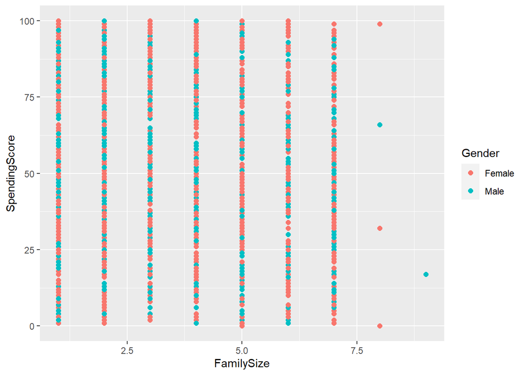

```r
ggplot(customers,
       aes(FamilySize,
           SpendingScore,
           color = Gender)) +
  geom_point(fill ="turquoise2", size = 2)
```

```r
ggsave('P1.png')
```

2nd Scatterplot graph shows the relationship between Age Vs work experience on basis of profession.

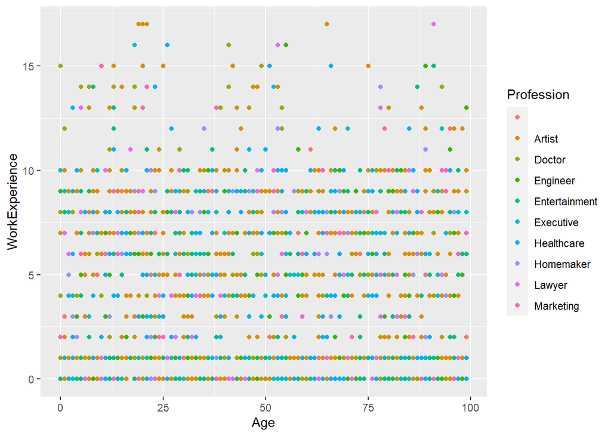

```r
ggplot(customers,
       aes(Age, WorkExperience,
           color = Profession)) +
  geom_point(fill= "palegreen1")
```

```r
ggsave('p2.png')
```

Overall, this scatters plot provides insight into the relationship between age and work experience for different professions.

3rd Scatterplot graph shows the relationship between spending score Vs Annual Income on basis of profession.

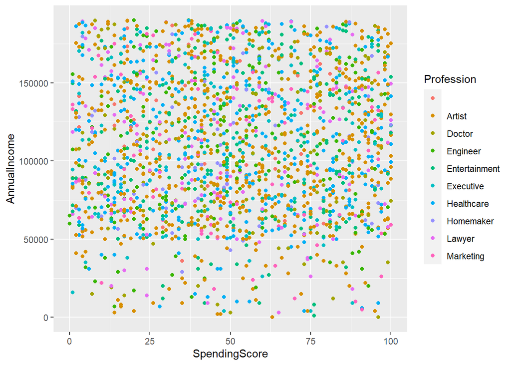

```r
ggplot(customers,
       aes(SpendingScore, AnnualIncome,
           color = Profession)) +
  geom_point(fill= "skyblue1")
```

```r
ggsave('p3.png')
```

## Box Plot

1st Boxplot graph shows the relationship between Annual Income Vs Profession.

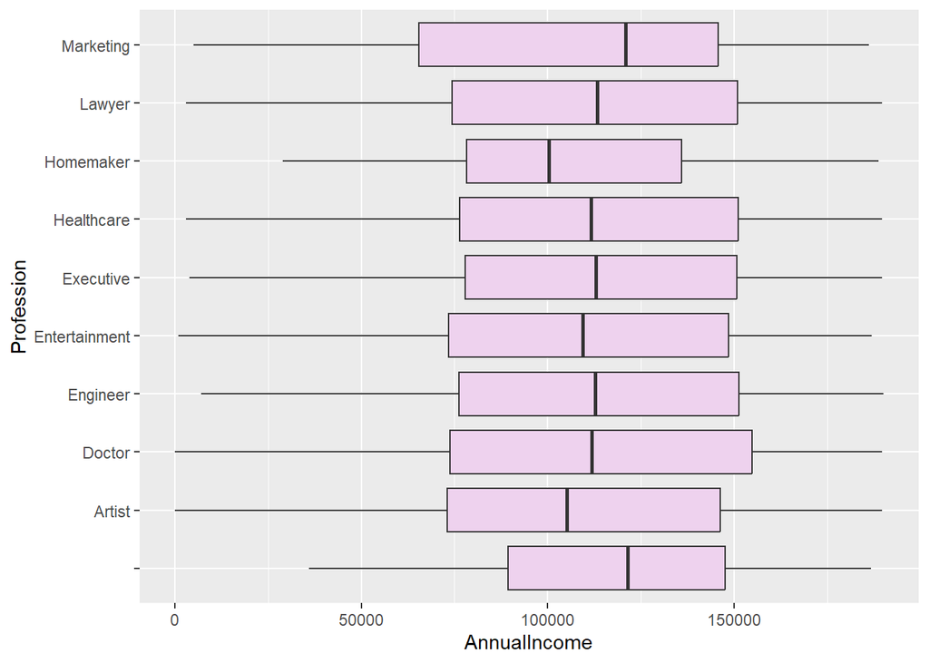

```r
ggplot(customers,
       aes(AnnualIncome,
           Profession)) +
  geom_boxplot(fill= "thistle2")
```

```r
ggsave('p4.png')
```

Overall, this plot gives us a good idea of the distribution of annual income for different professions, which can help us identify trends and make informed decisions.

2nd Boxplot graph shows the relationship between spending Score Vs Profession.

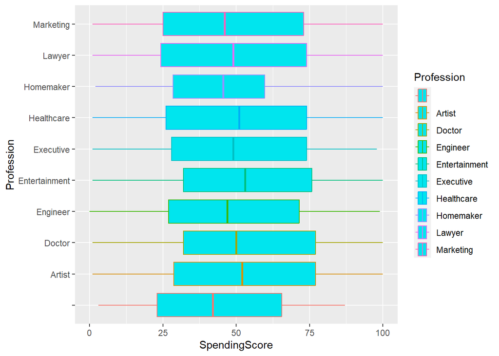

```r
ggplot(customers,
       aes(SpendingScore,
           Profession,
           color = Profession)) +
  geom_boxplot(fill ="turquoise2")
```

```r
ggsave('p5.png')
```

## Bar chart

Here Bar chart Shows the relationship between Spending Score and Gender.

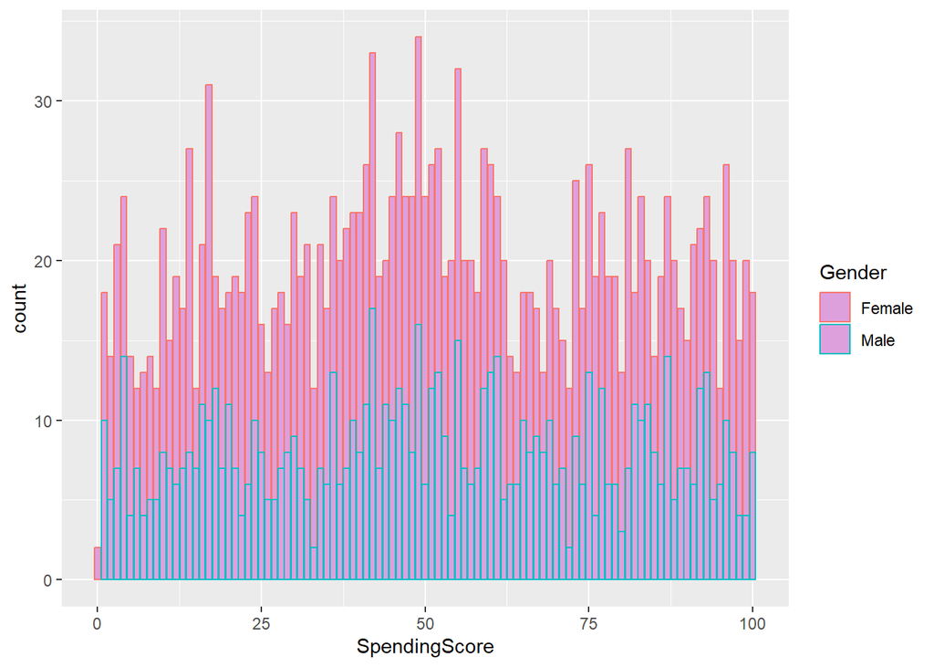

```r
ggplot(customers,
       aes(SpendingScore,
           color = Gender)) +
  geom_bar(fill ="plum")
```

```r
ggsave('p6.png')
```

## Histogram

Here Histogram shows the relationship between spending Score and Profession.

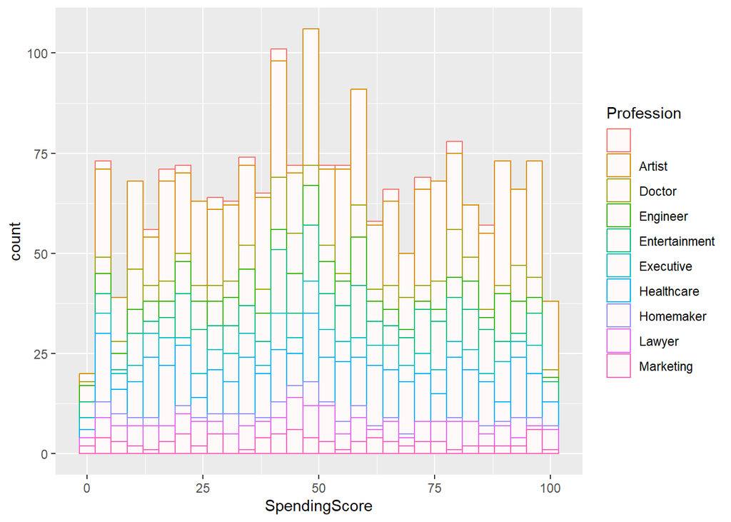

```r
ggplot(customers,
       aes(SpendingScore,
           color = Profession)) +
  geom_histogram(fill="snow")
```

```r
ggsave('p7.png')
```

## Correlation

1st correlation shows the relationship between Age and Family Size.

```r
customers <- read.csv("Customers.csv")
cor.test(customers$Age, customers$FamilySize, method = "spearman")
```

```
##
##  Spearman's rank correlation rho
##
## data:  customers$Age and customers$FamilySize
## S = 1280876395, p-value = 0.07857
## alternative hypothesis: true rho is not equal to 0
## sample estimates:
##        rho
## 0.03934246
```

The cor.test() function was used to calculate the Spearman’s rank correlation coefficient (rho) between the variables customers$Age and customers$FamilySize.

The computed value of rho is 0.03934246, indicating a very weak positive correlation between the two variables.

The p-value obtained from the test is 0.07857, which is higher than the typical level of significance of 0.05.

This implies that there is insufficient evidence to reject the null hypothesis that there is no correlation between the two variables. Hence, we cannot draw a conclusion that there is a statistically significant correlation between age and family size based on this analysis.

```r
cor(select(customers, Age, FamilySize))
```

```
##                   Age FamilySize
## Age        1.00000000 0.03825438
## FamilySize 0.03825438 1.00000000
```

The output above displays the correlation matrix for the variables Age and FamilySize in the customer’s dataset.

The computed correlation coefficient between Age and FamilySize is 0.03825438, which implies a very weak positive correlation between the two variables.

Furthermore, the correlation coefficient between Age and itself is 1, as expected, since any variable has a perfect correlation with itself.

The same holds true for FamilySize and itself, which also has a correlation coefficient of 1.

In conclusion, this output suggests that there is little to no meaningful correlation between Age and FamilySize in the customer’s dataset.

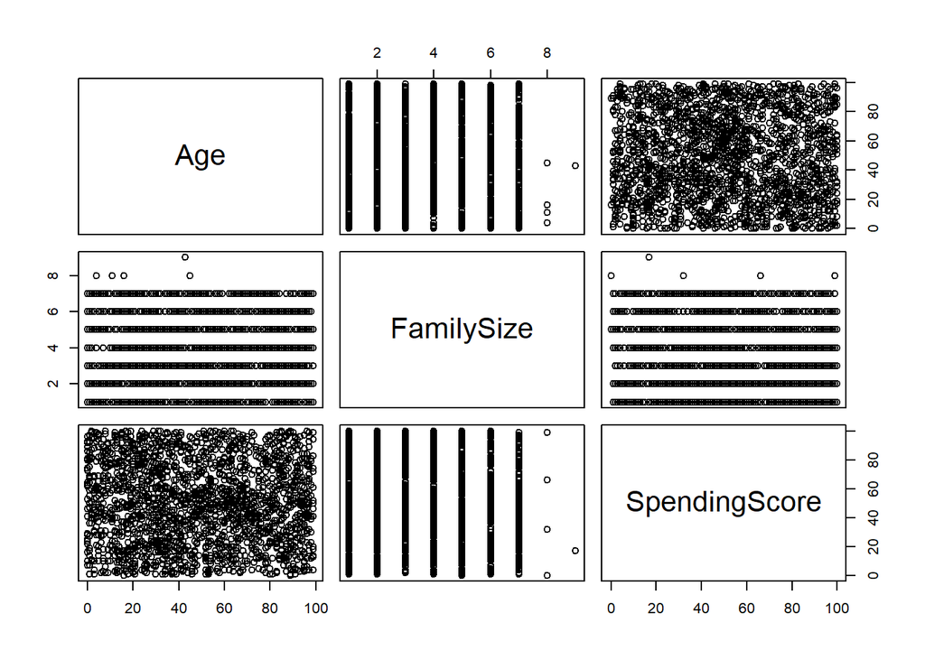

```r
pairs(select(customers, Age, FamilySize,SpendingScore))
```

From the image it is seen that there is no relation between the 3 variables.

2nd correlation exists between work experience and Family Size.

```r
customers <- read.csv("Customers.csv")
cor.test(customers$WorkExperience, customers$FamilySize, method = "spearman")
```

```
##
##  Spearman's rank correlation rho
##
## data:  customers$WorkExperience and customers$FamilySize
## S = 1316329885, p-value = 0.5687
## alternative hypothesis: true rho is not equal to 0
## sample estimates:
##        rho
## 0.01275234
```

This output is the result of performing a Spearman’s rank correlation test between WorkExperience and FamilySize.

The correlation coefficient between the two variables is 0.01275234, indicating a very weak positive relationship. The p-value of 0.5687 suggests that there is no statistically significant evidence to reject the null hypothesis of zero correlation between the two variables at the 5% significance level.

Therefore, we can conclude that there is no significant correlation between WorkExperience and FamilySize based on this test.

```r
cor(select(customers, WorkExperience, FamilySize))
```

```
##                WorkExperience FamilySize
## WorkExperience     1.00000000 0.01187302
## FamilySize         0.01187302 1.00000000
```

This output shows the result of a Pearson’s correlation coefficient calculation between WorkExperience and FamilySize variables in customers’ data frame.

The correlation coefficient between the two variables is 0.01187302, which indicates a very weak positive relationship.

As the correlation coefficient is close to zero, there is no significant linear correlation between the two variables.

We can conclude that there is no significant linear association between WorkExperience and FamilySize in the customer’s data frame based on this test.

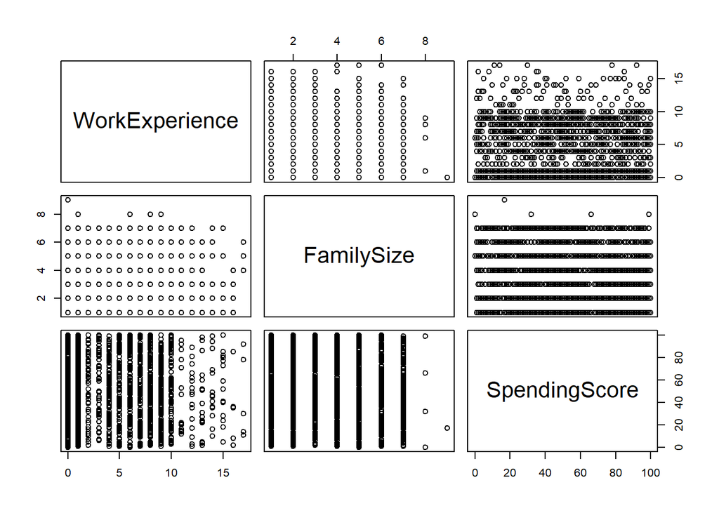

```r
pairs(select(customers, WorkExperience, FamilySize,SpendingScore))
```

From the image it is seen that there is very week relation between the 3 variables.

## Linear Regression

1st Linear Regression exists between the Family Size and annual Income.

```r
customers <- read.csv("Customers.csv")
linear_customer <- lm(customers$FamilySize ~ customers$AnnualIncome, data = customers)
summary(linear_customer)
```

```
##
## Call:
## lm(formula = customers$FamilySize ~ customers$AnnualIncome, data = customers)
##
## Residuals:
##     Min      1Q  Median      3Q     Max
## -3.0860 -1.6894 -0.0106  1.4621  5.5550
##
## Coefficients:
##                         Estimate Std. Error t value Pr(>|t|)
## (Intercept)            3.325e+00  1.150e-01  28.916  < 2e-16 ***
## customers$AnnualIncome 4.007e-06  9.597e-07   4.175  3.1e-05 ***
## ---
## Signif. codes:  0 '***' 0.001 '**' 0.01 '*' 0.05 '.' 0.1 ' ' 1
##
## Residual standard error: 1.963 on 1998 degrees of freedom
## Multiple R-squared:  0.00865,    Adjusted R-squared:  0.008154
## F-statistic: 17.43 on 1 and 1998 DF,  p-value: 3.103e-05
```

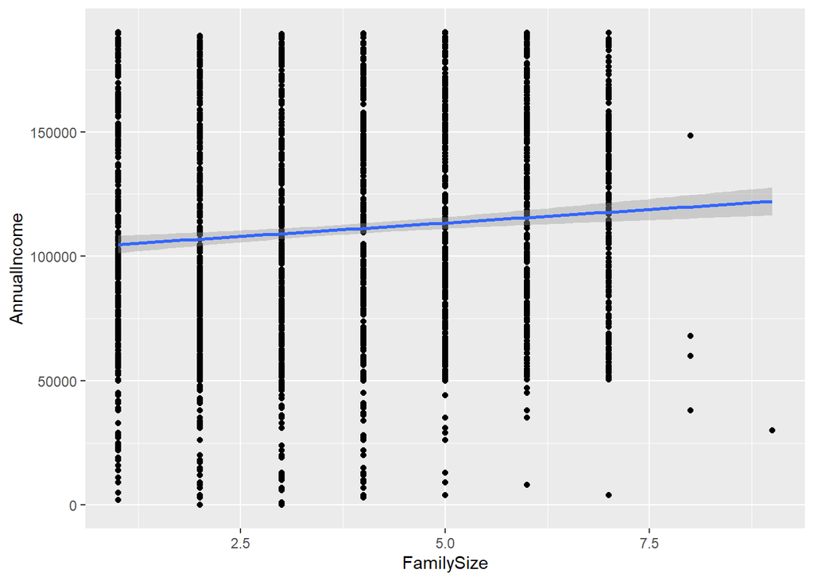

```r
ggplot(customers, aes(FamilySize, AnnualIncome)) +
  geom_point() +
  geom_smooth(method=lm)
```

```r
ggsave("Linear_regression1.png")
```

This output displays the outcome of a linear regression analysis between the FamilySize and AnnualIncome variables from the customers data frame.

The regression coefficient for AnnualIncome is 4.007e-06, indicating that a unit increase in AnnualIncome is associated with a 4.007e-06 increase in FamilySize.

The intercept value of the model is 3.325, which means that when AnnualIncome is zero, FamilySize is expected to be 3.325.

The p-value associated with AnnualIncome is below 0.05, indicating that the coefficient is statistically significant, suggesting that there is a significant positive relationship between AnnualIncome and FamilySize. However, the multiple R-squared values of 0.00865 suggests that only 0.87% of the variance in FamilySize is explained by AnnualIncome.

Overall, the results of the linear regression model suggest that AnnualIncome and FamilySize have a statistically significant positive relationship, but the model has limited explanatory power, explaining only a small proportion of the variation in FamilySize.

2nd Linear Regression exists between the Work Experience and annual Income.

```r
linear_customer <- lm(customers$AnnualIncome ~ customers$WorkExperience, data = customers)
summary(linear_customer)
```

```
##
## Call:
## lm(formula = customers$AnnualIncome ~ customers$WorkExperience,
##     data = customers)
##
## Residuals:
##     Min      1Q  Median      3Q     Max
## -108665  -36320   -1933   38272   83478
##
## Coefficients:
##                          Estimate Std. Error t value Pr(>|t|)
## (Intercept)              106467.4     1474.7    72.2  < 2e-16 ***
## customers$WorkExperience   1039.5      259.9     4.0 6.56e-05 ***
## ---
## Signif. codes:  0 '***' 0.001 '**' 0.01 '*' 0.05 '.' 0.1 ' ' 1
##
## Residual standard error: 45570 on 1998 degrees of freedom
## Multiple R-squared:  0.007945,   Adjusted R-squared:  0.007449
## F-statistic:    16 on 1 and 1998 DF,  p-value: 6.559e-05
```

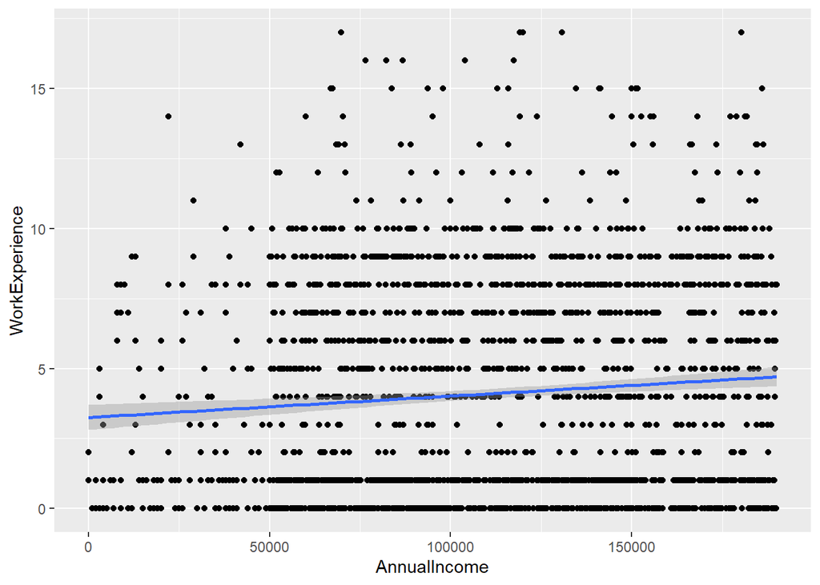

```r
ggplot(customers, aes(AnnualIncome, WorkExperience)) +
  geom_point() +
  geom_smooth(method=lm)
```

```r
ggsave("Linear_regression2.png")
```

This output presents the result of a linear regression model between AnnualIncome and WorkExperience variables in the customers data frame. The regression coefficient for WorkExperience is 1039.5, indicating that for every unit increase in WorkExperience, there is an increase of 1039.5 in AnnualIncome. The intercept of the model is 106467.4, which suggests that when WorkExperience is zero, AnnualIncome is expected to be 106467.4.

The p-value associated with WorkExperience is less than 0.05, which means that the coefficient is statistically significant. This indicates that there is a significant positive relationship between WorkExperience and AnnualIncome. The multiple R-squared value of 0.007945 suggests that only 0.79% of the variability in AnnualIncome can be explained by WorkExperience.

In summary, the linear regression model indicates that there is a statistically significant positive relationship between WorkExperience and AnnualIncome, but the model explains only a small proportion of the variation in AnnualIncome.

## T-Test

1st t-test exists between male and female spending scores.

```r
customers <- read.csv("customers.csv")
males <- subset(customers, Gender == "Male")
females <- subset(customers, Gender == "Female")
t.test(males$SpendingScore, females$SpendingScore, var.equal = FALSE)
```

```
##
##  Welch Two Sample t-test
##
## data:  males$SpendingScore and females$SpendingScore
## t = -0.023614, df = 1756.4, p-value = 0.9812
## alternative hypothesis: true difference in means is not equal to 0
## 95 percent confidence interval:
##  -2.520631  2.460656
## sample estimates:
## mean of x mean of y
##  50.94472  50.97470
```

The output shows the results of a two-sample t-test to compare the spending scores between males and females.

The null hypothesis is that there is no difference in the mean spending scores between males and females.

The alternative hypothesis is that the mean spending scores are different for males and females.

The t-statistic is -0.023614 and the degrees of freedom are 1756.4.

The p-value is 0.9812, which is greater than the significance level of 0.05.

Therefore, we fail to reject the null hypothesis and conclude that there is no significant difference in the mean spending scores between males and females.

The 95% confidence interval for the difference in means is [-2.520631, 2.460656], which contains zero, further supporting the null hypothesis. The sample means for males and females are 50.94472 and 50.97470, respectively.

```r
Age_A <- subset(customers, customers$Age > 50)
Age_B <- subset(customers, customers$Age <= 50)
t.test(Age_A$SpendingScore, Age_B$SpendingScore, var.equal = FALSE)
```

```
##
##  Welch Two Sample t-test
##
## data:  Age_A$SpendingScore and Age_B$SpendingScore
## t = -1.2209, df = 1990.7, p-value = 0.2223
## alternative hypothesis: true difference in means is not equal to 0
## 95 percent confidence interval:
##  -3.9743111  0.9246314
## sample estimates:
## mean of x mean of y
##  50.16806  51.69290
```

This output shows the results of a two-sample t-test to compare the spending scores between two groups labeled Age_A and Age_B.

The null hypothesis is that there is no difference in the mean spending scores between these two groups.

The alternative hypothesis is that the mean spending scores are different between the two groups.

The t-statistic is -1.2209 and the degrees of freedom are 1990.7.

The pvalue is 0.2223, which is greater than the significance level of 0.05.

Therefore, we fail to reject the null hypothesis and conclude that there is no significant difference in the mean spending scores between Age_A and Age_B.

The 95% confidence interval for the difference in means is [-3.9743111, 0.9246314], which contains zero, further supporting the null hypothesis.

The sample means for Age_A and Age_B are 50.16806 and 51.69290, respectively.